# ADP Practice 4

Ku, Bonseong

2020 12 9

## 데이터, 패키지 로드

```r
library(rpart)
library(rpart.plot)
library(randomForest)
library(e1071)
library(ROCR)
library(caret)
library(lmtest)
library(tm)
library(rJava)
library(KoNLP)
library(wordcloud)
library(plyr)
library(stringr)

AUS<-read.csv('weatherAUS.csv')
bike<-read.csv('bike_marketing.csv')
instagram_tour<-readLines("instagram_태교여행.txt")
set.seed(6789)
```

## 정형 데이터마이닝

### 데이터 전처리, 스플릿

```r
summary(AUS)
```

```
##          Date            Location         MinTemp         MaxTemp
##  2013-03-02:    49   Canberra:  3418   Min.   :-8.50   Min.   :-4.80
##  2013-03-03:    49   Sydney  :  3337   1st Qu.: 7.60   1st Qu.:17.90
##  2013-03-04:    49   Perth   :  3193   Median :12.00   Median :22.60
##  2013-03-06:    49   Darwin  :  3192   Mean   :12.19   Mean   :23.23
##  2013-03-07:    49   Hobart  :  3188   3rd Qu.:16.80   3rd Qu.:28.20
##  2013-03-10:    49   Brisbane:  3161   Max.   :33.90   Max.   :48.10
##  (Other)   :141899   (Other) :122704   NA's   :637     NA's   :322
##     Rainfall       WindGustDir    WindGustSpeed      WindDir9am
##  Min.   :  0.00   W      : 9780   Min.   :  6.00   N      :11393
##  1st Qu.:  0.00   SE     : 9309   1st Qu.: 31.00   SE     : 9162
##  Median :  0.00   E      : 9071   Median : 39.00   E      : 9024
##  Mean   :  2.35   N      : 9033   Mean   : 39.98   SSE    : 8966
##  3rd Qu.:  0.80   SSE    : 8993   3rd Qu.: 48.00   NW     : 8552
##  Max.   :371.00   (Other):86677   Max.   :135.00   (Other):85083
##  NA's   :1406     NA's   : 9330   NA's   :9270     NA's   :10013
##    WindDir3pm     WindSpeed9am   WindSpeed3pm    Humidity9am
##  SE     :10663   Min.   :  0    Min.   : 0.00   Min.   :  0.00
##  W      : 9911   1st Qu.:  7    1st Qu.:13.00   1st Qu.: 57.00
##  S      : 9598   Median : 13    Median :19.00   Median : 70.00
##  WSW    : 9329   Mean   : 14    Mean   :18.64   Mean   : 68.84
##  SW     : 9182   3rd Qu.: 19    3rd Qu.:24.00   3rd Qu.: 83.00
##  (Other):89732   Max.   :130    Max.   :87.00   Max.   :100.00
##  NA's   : 3778   NA's   :1348   NA's   :2630    NA's   :1774
##   Humidity3pm      Pressure9am      Pressure3pm        Cloud9am
##  Min.   :  0.00   Min.   : 980.5   Min.   : 977.1   Min.   :0.00
##  1st Qu.: 37.00   1st Qu.:1012.9   1st Qu.:1010.4   1st Qu.:1.00
##  Median : 52.00   Median :1017.6   Median :1015.2   Median :5.00
##  Mean   : 51.48   Mean   :1017.7   Mean   :1015.3   Mean   :4.44
##  3rd Qu.: 66.00   3rd Qu.:1022.4   3rd Qu.:1020.0   3rd Qu.:7.00
##  Max.   :100.00   Max.   :1041.0   Max.   :1039.6   Max.   :9.00
##  NA's   :3610     NA's   :14014    NA's   :13981    NA's   :53657
##     Cloud3pm        Temp9am         Temp3pm      RainToday
##  Min.   :0.0     Min.   :-7.20   Min.   :-5.40   No  :109332
##  1st Qu.:2.0     1st Qu.:12.30   1st Qu.:16.60   Yes : 31455
##  Median :5.0     Median :16.70   Median :21.10   NA's:  1406
##  Mean   :4.5     Mean   :16.99   Mean   :21.69
##  3rd Qu.:7.0     3rd Qu.:21.60   3rd Qu.:26.40
##  Max.   :9.0     Max.   :40.20   Max.   :46.70
##  NA's   :57094   NA's   :904     NA's   :2726
##  RainTomorrow
##  No :110316
##  Yes: 31877
##
##
##
##
##
```

```r
AUS_1<-AUS[,-c(8,14,15,16,17)]
AUS_1$Date<-as.Date(AUS_1$Date)
AUS_1<-na.omit(AUS_1) # 결측치 제거
sum(is.na(AUS_1))
```

```
## [1] 0
```

```r
AUS_1<-AUS_1[0:1000,] # 데이터 1000개만 이용, 원래는 fulldata 해야하지만 연습이니까...

idx<-sample(1:nrow(AUS_1),size=nrow(AUS_1)*0.7,replace=FALSE)
AUS_train<-AUS_1[idx,]
AUS_test<-AUS_1[-idx,]
cat(nrow(AUS_train),nrow(AUS_test))
```

```
## 700 300
```

### 의사결정나무

#### 모형적합

```r
tree.fit<-rpart(RainTomorrow~., data=AUS_train, method="class", control = rpart.control(maxdepth=5, minsplit=15))
tree.fit
```

```
## n= 700
##
## node), split, n, loss, yval, (yprob)
##       * denotes terminal node
##
##  1) root 700 159 No (0.77285714 0.22714286)
##    2) Humidity3pm< 66.5 581  70 No (0.87951807 0.12048193)
##      4) WindGustSpeed< 53 534  48 No (0.91011236 0.08988764)
##        8) WindGustDir=E,ESE,S,SE,SSE,SSW,SW,W,WNW,WSW 376  14 No (0.96276596 0.03723404) *
##        9) WindGustDir=ENE,N,NE,NNE,NNW,NW 158  34 No (0.78481013 0.21518987)
##         18) Humidity3pm< 49.5 98  11 No (0.88775510 0.11224490) *
##         19) Humidity3pm>=49.5 60  23 No (0.61666667 0.38333333)
##           38) WindDir3pm=ESE,NNW,NW,S,SE,SSE,WNW,WSW 28   4 No (0.85714286 0.14285714) *
##           39) WindDir3pm=E,ENE,N,NE,NNE,W 32  13 Yes (0.40625000 0.59375000) *
##      5) WindGustSpeed>=53 47  22 No (0.53191489 0.46808511)
##       10) Humidity3pm< 37 19   2 No (0.89473684 0.10526316) *
##       11) Humidity3pm>=37 28   8 Yes (0.28571429 0.71428571)
##         22) WindDir3pm=ENE,SSW,W,WNW,WSW 15   7 No (0.53333333 0.46666667)
##           44) WindSpeed9am< 23 9   1 No (0.88888889 0.11111111) *
##           45) WindSpeed9am>=23 6   0 Yes (0.00000000 1.00000000) *
##         23) WindDir3pm=N,NE,NNW,NW,SE,SSE,SW 13   0 Yes (0.00000000 1.00000000) *
##    3) Humidity3pm>=66.5 119  30 Yes (0.25210084 0.74789916)
##      6) WindGustSpeed< 21 19   6 No (0.68421053 0.31578947)
##       12) WindDir3pm=E,ENE,S,SE,SSE,SW,WSW 11   0 No (1.00000000 0.00000000) *
##       13) WindDir3pm=ESE,NE,NNE,W 8   2 Yes (0.25000000 0.75000000) *
##      7) WindGustSpeed>=21 100  17 Yes (0.17000000 0.83000000)
##       14) WindDir3pm=SE,SSW,W,WNW,WSW 41  15 Yes (0.36585366 0.63414634)
##         28) WindGustSpeed< 41 25  12 No (0.52000000 0.48000000)
##           56) WindGustSpeed>=34 7   0 No (1.00000000 0.00000000) *
##           57) WindGustSpeed< 34 18   6 Yes (0.33333333 0.66666667) *
##         29) WindGustSpeed>=41 16   2 Yes (0.12500000 0.87500000) *
##       15) WindDir3pm=E,ENE,ESE,N,NE,NNE,NNW,NW,S,SSE,SW 59   2 Yes (0.03389831 0.96610169) *
```

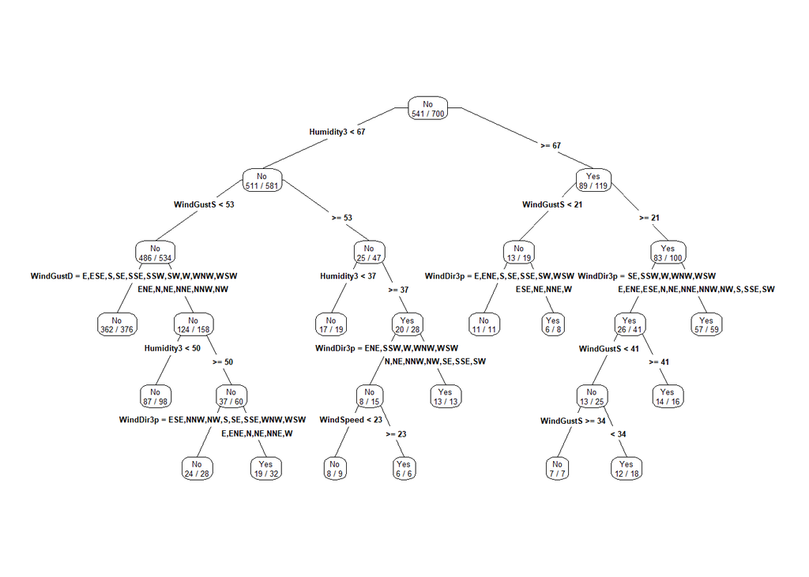

```r
prp(tree.fit,type=4,extra = 2)
```

```r
pred_tree<-predict(tree.fit,AUS_test[,-length(AUS_test)],type='prob')
pred_tree2<-predict(tree.fit,AUS_test[,-length(AUS_test)],type='class')

write.csv(cbind(pred_tree,pred_tree2),'decisiontree.csv')
```

#### 모형평가

```r
confusionMatrix(data=pred_tree2,reference=AUS_test[,16], positive="Yes")
```

```
## Confusion Matrix and Statistics
##
##           Reference
## Prediction  No Yes
##        No  210  26
##        Yes  23  41
##
##                Accuracy : 0.8367
##                  95% CI : (0.7899, 0.8767)
##     No Information Rate : 0.7767
##     P-Value [Acc > NIR] : 0.006234
##
##                   Kappa : 0.5215
##
##  Mcnemar's Test P-Value : 0.775097
##
##             Sensitivity : 0.6119
##             Specificity : 0.9013
##          Pos Pred Value : 0.6406
##          Neg Pred Value : 0.8898
##              Prevalence : 0.2233
##          Detection Rate : 0.1367
##    Detection Prevalence : 0.2133
##       Balanced Accuracy : 0.7566
##
##        'Positive' Class : Yes
##
```

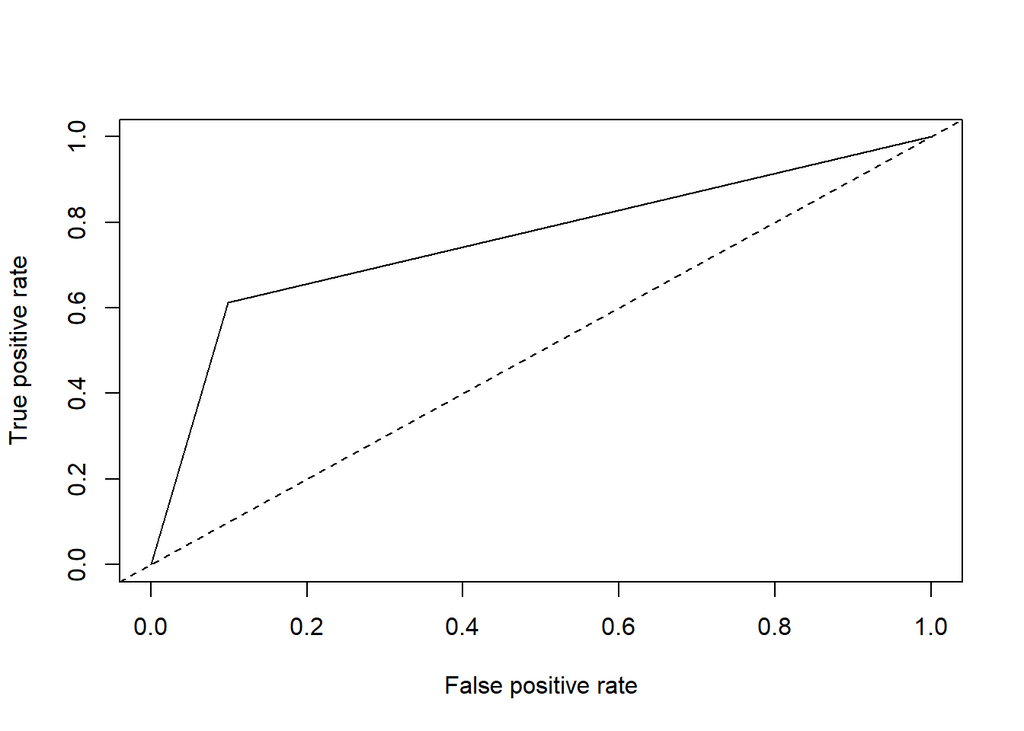

```r
pred.dt.roc<-prediction(as.numeric(pred_tree2),as.numeric(AUS_test[,16]))
plot(performance(pred.dt.roc,"tpr","fpr"))
abline(a=0,b=1,lty=2,col="black")
```

```r
performance(pred.dt.roc,"auc")@y.values
```

```
## [[1]]
## [1] 0.7566139
```

### 랜덤포레스트

```r
rf.fit<-randomForest(RainTomorrow~., data=AUS_train)
rf.fit
```

```
##
## Call:
##  randomForest(formula = RainTomorrow ~ ., data = AUS_train)
##                Type of random forest: classification
##                      Number of trees: 500
## No. of variables tried at each split: 3
##
##         OOB estimate of  error rate: 12.43%
## Confusion matrix:
##      No Yes class.error
## No  515  26  0.04805915
## Yes  61  98  0.38364780
```

```r
pred_rf<-predict(rf.fit, AUS_test[,-16], type='prob')
pred_rf2<-predict(rf.fit, AUS_test[,-16], type='class')

write.csv(cbind(pred_rf,pred_rf2), 'randomforest.csv')
```

#### 모형평가

```r
confusionMatrix(data=pred_rf2,reference=AUS_test[,16], positive="Yes")
```

```
## Confusion Matrix and Statistics
##
##           Reference
## Prediction  No Yes
##        No  219  21
##        Yes  14  46
##
##                Accuracy : 0.8833
##                  95% CI : (0.8415, 0.9174)
##     No Information Rate : 0.7767
##     P-Value [Acc > NIR] : 1.482e-06
##
##                   Kappa : 0.6507
##
##  Mcnemar's Test P-Value : 0.3105
##
##             Sensitivity : 0.6866
##             Specificity : 0.9399
##          Pos Pred Value : 0.7667
##          Neg Pred Value : 0.9125
##              Prevalence : 0.2233
##          Detection Rate : 0.1533
##    Detection Prevalence : 0.2000
##       Balanced Accuracy : 0.8132
##
##        'Positive' Class : Yes
##
```

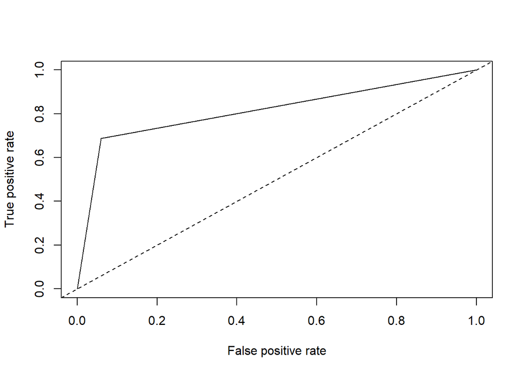

```r
pred.rf.roc<-prediction(as.numeric(pred_rf2),as.numeric(AUS_test[,16]))
plot(performance(pred.rf.roc,"tpr","fpr"))
abline(a=0,b=1,lty=2,col="black")
```

```r
performance(pred.rf.roc,"auc")@y.values
```

```
## [[1]]
## [1] 0.8132407
```

### 나이브베이즈

```r
nv.fit<-naiveBayes(RainTomorrow~., data=AUS_train)
```

```r
pred_nv<-predict(nv.fit, AUS_test[,-16], type='raw')
pred_nv2<-predict(nv.fit, AUS_test[,-16], type='class')
write.csv(cbind(pred_nv,pred_nv2), 'naivebayes.csv')
```

#### 모형평가

```r
confusionMatrix(data=pred_nv2,reference=AUS_test[,16], positive="Yes")
```

```
## Confusion Matrix and Statistics
##
##           Reference
## Prediction  No Yes
##        No  207  25
##        Yes  26  42
##
##                Accuracy : 0.83
##                  95% CI : (0.7826, 0.8707)
##     No Information Rate : 0.7767
##     P-Value [Acc > NIR] : 0.01384
##
##                   Kappa : 0.5126
##
##  Mcnemar's Test P-Value : 1.00000
##
##             Sensitivity : 0.6269
##             Specificity : 0.8884
##          Pos Pred Value : 0.6176
##          Neg Pred Value : 0.8922
##              Prevalence : 0.2233
##          Detection Rate : 0.1400
##    Detection Prevalence : 0.2267
##       Balanced Accuracy : 0.7576
##
##        'Positive' Class : Yes
##
```

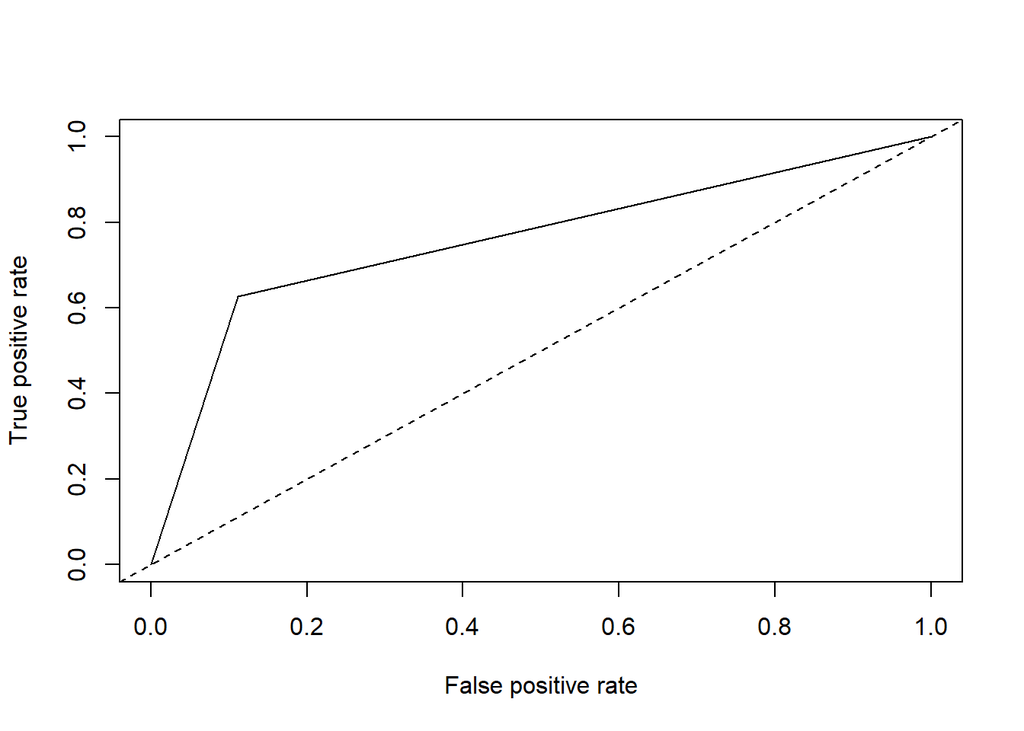

```r
pred.nv.roc<-prediction(as.numeric(pred_nv2),as.numeric(AUS_test[,16]))
plot(performance(pred.nv.roc,"tpr","fpr"))
abline(a=0,b=1,lty=2,col="black")
```

```r
performance(pred.nv.roc,"auc")@y.values
```

```
## [[1]]
## [1] 0.7576388
```

- 의사결정나무는 설명력이 다소 부족했다.
- 랜덤포레스트는 정확돠와 AUC 부분에 있어 가장 높은 수치를 기록했다.
- 나이브 베이즈 결과, 정확도가 83%로 높은 수치이지만, 랜덤포레스트에 비해 낮게 나왔다.
- 데이터의 특성에 따라 정확도를 제외한 특이도, 민감도 등도 함께 파악하여 해당 데이터에 가장 적절한 분석 모형을 선택해야 한다.

## 통계분석

```r
sum(is.na(bike)) #결측치 확인인
```

```
## [1] 0
```

```r
bike$pop_density<-as.factor(bike$pop_density)
```

### 분산분석

```r
summary(aov(revenues~pop_density, data=bike))
```

```
##              Df Sum Sq Mean Sq F value Pr(>F)
## pop_density   2     42   20.87    0.61  0.545
## Residuals   169   5781   34.21
```

### 회귀분석

```r
bike_lm<-lm(revenues~google_adwords+facebook+twitter+marketing_total+employees, data=bike)
summary(bike_lm)
```

```
##
## Call:
## lm(formula = revenues ~ google_adwords + facebook + twitter +
##     marketing_total + employees, data = bike)
##
## Residuals:
##     Min      1Q  Median      3Q     Max
## -5.7788 -1.2437  0.2024  1.4643  4.2835
##
## Coefficients:
##                 Estimate Std. Error t value Pr(>|t|)
## (Intercept)      28.4433     0.5962  47.706  < 2e-16 ***
## google_adwords    1.2110     0.5708   2.122 0.035348 *
## facebook          1.3464     0.5714   2.356 0.019618 *
## twitter           1.1724     0.5713   2.052 0.041711 *
## marketing_total  -1.1696     0.5708  -2.049 0.042033 *
## employees         0.3865     0.1042   3.708 0.000284 ***
## ---
## Signif. codes:  0 '***' 0.001 '**' 0.01 '*' 0.05 '.' 0.1 ' ' 1
##
## Residual standard error: 2.108 on 166 degrees of freedom
## Multiple R-squared:  0.8733, Adjusted R-squared:  0.8695
## F-statistic: 228.9 on 5 and 166 DF,  p-value: < 2.2e-16
```

- full 모형이다. 모든 변수가 유의하다.
- 모형의 결정계수는 0.8733이며 수정된 결정계수는 0.8695이다. 이 모형은 전체 데이터의 87.33% 를 설명한다.
- F통계량에 대한 p-value는 <0.05 이므로 통계적으로 유의하다.

```r
formula_low<-lm(revenues~1, data=bike)
formula_high<-bike_lm

bike_lm2<-step(formula_low, scope=list(upper=formula_high), direction='forward')
```

```
## Start:  AIC=607.8
## revenues ~ 1
##
##                   Df Sum of Sq    RSS    AIC
## + marketing_total  1    4235.3 1587.8 386.29
## + google_adwords   1    3418.9 2404.2 457.64
## + employees        1    3413.9 2409.2 458.00
## + facebook         1    1944.2 3878.9 539.92
## + twitter          1     423.5 5399.6 596.81
## <none>                         5823.1 607.80
##
## Step:  AIC=386.29
## revenues ~ marketing_total
##
##                  Df Sum of Sq     RSS    AIC
## + facebook        1    632.00  955.78 300.98
## + employees       1    276.11 1311.67 355.43
## + google_adwords  1     98.35 1489.43 377.29
## <none>                        1587.78 386.29
## + twitter         1     17.67 1570.11 386.36
##
## Step:  AIC=300.98
## revenues ~ marketing_total + facebook
##
##                  Df Sum of Sq    RSS    AIC
## + google_adwords  1   131.845 823.93 277.45
## + twitter         1   130.154 825.62 277.81
## + employees       1    98.114 857.66 284.36
## <none>                        955.78 300.99
##
## Step:  AIC=277.45
## revenues ~ marketing_total + facebook + google_adwords
##
##             Df Sum of Sq    RSS    AIC
## + employees  1    67.681 756.25 264.71
## + twitter    1    25.292 798.64 274.09
## <none>                   823.93 277.45
##
## Step:  AIC=264.71
## revenues ~ marketing_total + facebook + google_adwords + employees
##
##           Df Sum of Sq    RSS    AIC
## + twitter  1    18.713 737.54 262.40
## <none>                 756.25 264.71
##
## Step:  AIC=262.4
## revenues ~ marketing_total + facebook + google_adwords + employees +
##     twitter
```

```r
summary(bike_lm2)
```

```
##
## Call:
## lm(formula = revenues ~ marketing_total + facebook + google_adwords +
##     employees + twitter, data = bike)
##
## Residuals:
##     Min      1Q  Median      3Q     Max
## -5.7788 -1.2437  0.2024  1.4643  4.2835
##
## Coefficients:
##                 Estimate Std. Error t value Pr(>|t|)
## (Intercept)      28.4433     0.5962  47.706  < 2e-16 ***
## marketing_total  -1.1696     0.5708  -2.049 0.042033 *
## facebook          1.3464     0.5714   2.356 0.019618 *
## google_adwords    1.2110     0.5708   2.122 0.035348 *
## employees         0.3865     0.1042   3.708 0.000284 ***
## twitter           1.1724     0.5713   2.052 0.041711 *
## ---
## Signif. codes:  0 '***' 0.001 '**' 0.01 '*' 0.05 '.' 0.1 ' ' 1
##
## Residual standard error: 2.108 on 166 degrees of freedom
## Multiple R-squared:  0.8733, Adjusted R-squared:  0.8695
## F-statistic: 228.9 on 5 and 166 DF,  p-value: < 2.2e-16
```

- 전진선택법에 의해 최소모형 (잔차) 부터 최대모형 (full) 까지 변수를 선택한다.
- AIC를 낮추는 방향으로 변수를 선택한다.
- 그 결과, 모든 변수를 사용하는 것이 AIC가 가장 낮게 나왔다.

### 잔차분석

#### 독립성 가정 검정

```r
dwtest(bike_lm2)
```

```
##
##  Durbin-Watson test
##
## data:  bike_lm2
## DW = 2.1114, p-value = 0.7666
## alternative hypothesis: true autocorrelation is greater than 0
```

```r
shapiro.test(resid(bike_lm2))
```

```
##
##  Shapiro-Wilk normality test
##
## data:  resid(bike_lm2)
## W = 0.98658, p-value = 0.0991
```

- 정규성 가정을 샤피로윌크 테스트를 한 결과, p-value>0.05 이다.
- 귀무가설인 데이터가 정규성을 따른다를 채택한다. 따라서 정규성을 만족한다고 할 수 있다.

#### 등분산성 검정

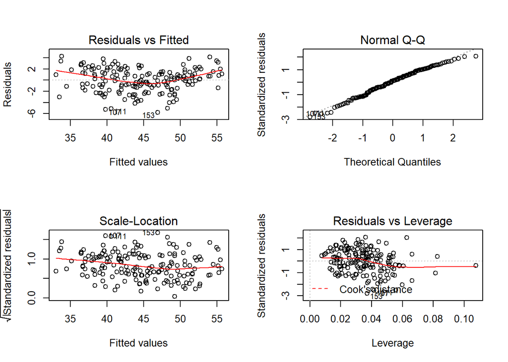

```r
par(mfrow=c(2,2))
plot(bike_lm2)
```

```r
par(mfrow=c(1,1))
```

- 1번 차트에서 그래프의 기울기가 x축과 평행하다고 보기 어렵다. 따라서 등분산성은 만족되는 것이 아닌걸로 보인다.
- 2번 차트는 점들이 주로 직선위에 있으므로 정규성을 만족한다고 볼 수 있따.
- 3번 차트는 빨간선의 기울기가 0에 가까워야 하지만, Fitted Values가 커질수록 기울기가 다소 변화하는 경향을 보이고 있다. 이렇게 빨간선의 기울기가 0에서 떨어진 점이 있따면 해당 점에서는 표준화 잔차가 큼을 의미하고, 회귀 직선이 y값을 잘 적합하지 못함을 의미한다. 또한 해당 점들은 이상치일 가능성이 있다.
- 4번 차트는 빨간 점선으로 표현되는 쿡의 거리가 0.5이상이면 빨간 점선 으로 표현되고, 점선 바깥에 있는 점들은 무시할 수 없을 정도로 예측치를 벗어난 값이다. 본 그래프에서 그러한 점들은 보이지 않으므로 회귀직선에 크게 영향을 끼치는 점들은 드물다고 볼 수 있다.
- 잔차분석 결과, 등분산성을 만족하다고 보기 어렵기 때문에, 본 모형은 활용하기 어렵다.

## 비정형 데이터 마이닝

```r
clean_txt<-function(txt){
  txt<-tolower(txt)             # 대, 소문자 변환
  txt<-removePunctuation(txt)   # 구두점 제거
  txt<-removeNumbers(txt)       # 숫자 제거
  txt<-stripWhitespace(txt)     # 공백제거

  return(txt)
}
tour_1<-clean_txt(instagram_tour)
head(tour_1)
```

```
## [1] "쇼퍼걸 예비맘 태교여행 괌 임신개월 배 부르게 밥 먹고 오빠 생일선물 산다고 다니다가 뜻밖에 내 가방도 득템 가방더 안실려고했는데 앙 기분 완전 좋음 이제 렌트하고 돌아댕기야지 "
## [2] "태교여행 몰디브 한식을 꼭 먹어야 했었던 임산부 땜에 남편은 몰디브에서도 김치찌개를 끓였어야 했다"
## [3] "하음이가 사랑이 뱃속에 있은 지 임신개월째 여행가서 찍은 사진 여행이라고는 하지만 온통 머릿속은 사랑이 건강과 더불어 개월 후 빛을 볼 하음이에 쏠려 있어 시드니의 분위기와 풍경보다는 우리 둘의 시간에 집중했던 sidney 부부 태교여행 호주 시드니 오페라하우스 아이고 멋져라 임신개월"
## [4] "행복했던 제주여행 화창한 날씨 푸르른 바다 맑고 쾌청한 하늘 나는 오늘 바다 와 깔맞춤 블루뚜ㅋㅋ instadaily daily dailylook selfie 셀피 제주도 용머리해안 힐링 바다스타그램 임산부 태교여행 폭스베스트 겨울코디 뚜뚜 뚜뚜네"
## [5] "떠나자 오키나와 hyenitwinkle 별똥이와 함께 떠나는 호야와 혜니의 태교여행 supreme supremetnf supremeundercover nmc pumphoya 슈프림 섭리미 슈노 슈노캐리어 슈언코치 나매 슈매 펌프호야 태교여행 오키나와"
## [6] "어제 아침 양치만하고 수영하러 사진찍는데 방해되니까 비켜주세요 토리아빠 괌 guam 태교여행 여행스타그램 예비맘 닭띠맘 셀스타그램 셀카 여유로운아침"
```

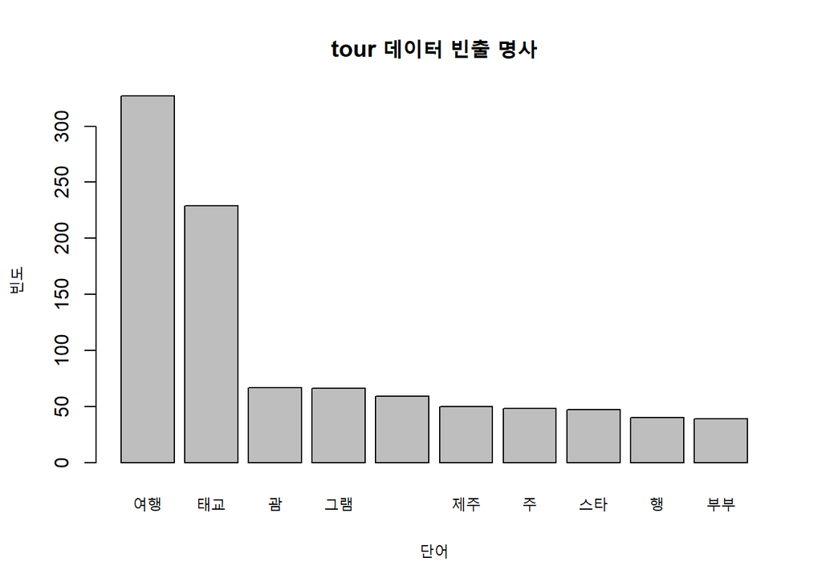

```r
tour1<-sapply(tour_1,extractNoun)

table.cnoun<-head(sort(table(unlist(tour1)),decreasing=T),10)

barplot(table.cnoun, main="tour 데이터 빈출 명사",
        xlab="단어",
        ylab="빈도")
```

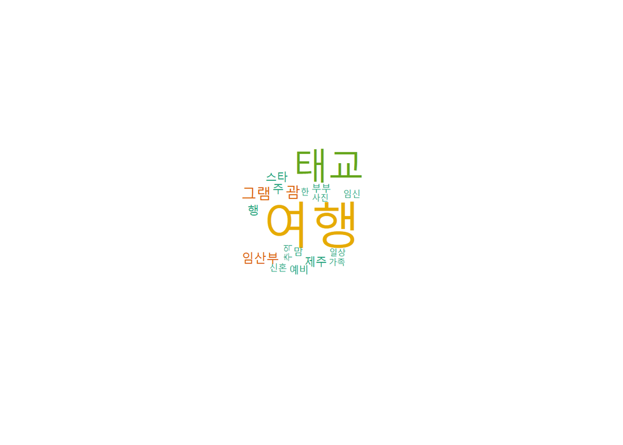

```r
result<-data.frame(sort(table(unlist(tour1)),decreasing=T))

t<-wordcloud(result$Var1,result$Freq,color=brewer.pal(6,"Dark2"),min.freq=20)
```